# Bikeshare_SpaceTime_Prediction

## Visualize Weather Patterns

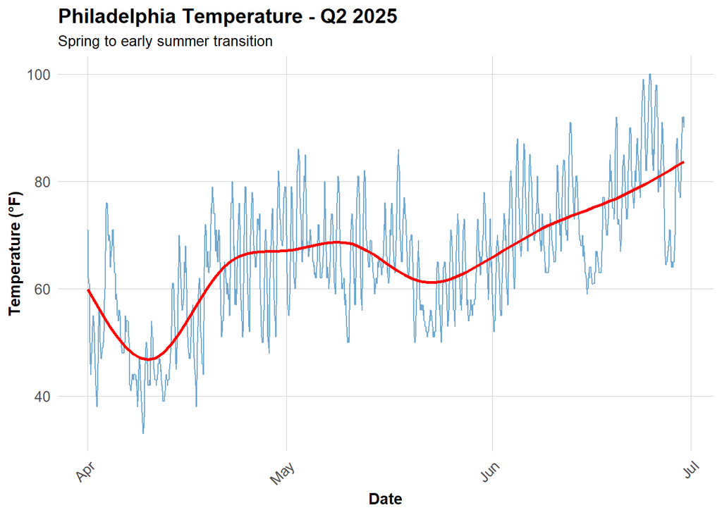

```r
ggplot(weather_complete, aes(x = interval60, y = Temperature)) +
  geom_line(color = "#3182bd", alpha = 0.7) +
  geom_smooth(se = FALSE, color = "red") +
  labs(
    title = "Philadelphia Temperature - Q2 2025",
    subtitle = "Spring to early summer transition",
    x = "Date",
    y = "Temperature (°F)"
  ) +
  plotTheme
```

# CREATE SPACE-TIME PANEL

## Aggregate Trips to Station-Hour Level

```r
# Count trips by station-hour
trips_panel <- indego_census %>%
  group_by(interval60, start_station, start_lat, start_lon,
           Med_Inc, Percent_Taking_Transit, Percent_White, Total_Pop) %>%
  summarize(Trip_Count = n()) %>%
  ungroup()

# How many station-hour observations?
nrow(trips_panel)
```

```
[1] 179107
```

```r
# How many unique stations?
length(unique(trips_panel$start_station))
```

```
[1] 252
```

```r
# How many unique hours?
length(unique(trips_panel$interval60))
```

```
[1] 2177
```

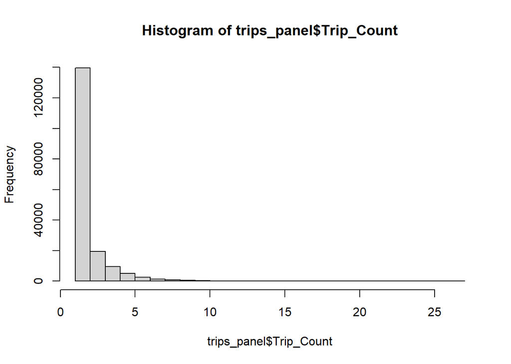

```r
hist(trips_panel$Trip_Count)
```

## Create Complete Panel Structure

Not every station has trips every hour. We need a **complete panel** where every station-hour combination exists (even if Trip_Count = 0).

```r
# Calculate expected panel size
n_stations <- length(unique(trips_panel$start_station))
n_hours <- length(unique(trips_panel$interval60))
expected_rows <- n_stations * n_hours

cat("Expected panel rows:", format(expected_rows, big.mark = ","), "\n")
```

```
Expected panel rows: 548,604
```

```r
cat("Current rows:", format(nrow(trips_panel), big.mark = ","), "\n")
```

```
Current rows: 179,107
```

```r
cat("Missing rows:", format(expected_rows - nrow(trips_panel), big.mark = ","), "\n")
```

```
Missing rows: 369,497
```

```r
# Create complete panel
study_panel <- expand_grid(
  interval60 = unique(trips_panel$interval60),
  start_station = unique(trips_panel$start_station)
) %>%
  # Join trip counts
  left_join(trips_panel %>%
              select(interval60, start_station, Trip_Count),
            by = c("interval60", "start_station")) %>%
  # Replace NA trip counts with 0
  mutate(Trip_Count = replace_na(Trip_Count, 0))

glimpse(study_panel)
```

```
Rows: 548,604
Columns: 3
$ interval60    <dttm> 2025-04-01, 2025-04-01, 2025-04-01, 2025-04-01, 2025-04…
$ start_station <dbl> 3022, 3040, 3054, 3280, 3301, 3396, 3158, 3371, 3374, 30…
$ Trip_Count    <int> 1, 1, 1, 1, 1, 1, 0, 0, 0, 0, 0, 0, 0, 0, 0, 0, 0, 0, 0,…
```

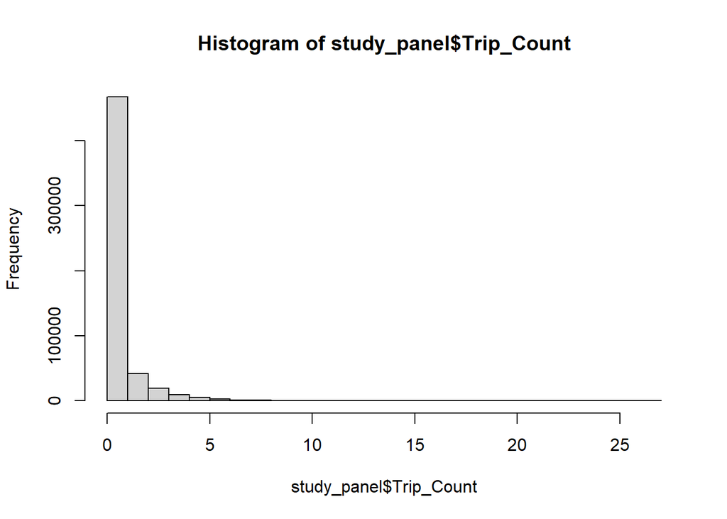

```r
hist(study_panel$Trip_Count)
```

```r
# Fill in station attributes (they're the same for all hours)
station_attributes <- trips_panel %>%
  group_by(start_station) %>%
  summarize(
    start_lat = first(start_lat),
    start_lon = first(start_lon),
    Med_Inc = first(Med_Inc),
    Percent_Taking_Transit = first(Percent_Taking_Transit),
    Percent_White = first(Percent_White),
    Total_Pop = first(Total_Pop)
  )

glimpse(station_attributes)
```

```
Rows: 252
Columns: 7
$ start_station          <dbl> 3005, 3006, 3007, 3008, 3009, 3010, 3012, 3014,…
$ start_lat              <dbl> 39.94733, 39.95220, 39.94517, 39.98081, 39.9557…
$ start_lon              <dbl> -75.14403, -75.20311, -75.15993, -75.15067, -75…
$ Med_Inc                <dbl> 144922, 21064, 58557, 22244, 37674, 88583, 1385…
$ Percent_Taking_Transit <dbl> 11.742827, 9.418565, 11.401515, 27.430556, 10.8…
$ Percent_White          <dbl> 86.29640, 46.88109, 62.85341, 39.65227, 60.2169…
$ Total_Pop              <dbl> 3583, 6156, 4598, 5349, 7375, 3134, 3643, 3914,…
```

```r
study_panel <- study_panel %>%
  left_join(station_attributes, by = "start_station")

glimpse(study_panel)
```

```
Rows: 548,604
Columns: 9
$ interval60             <dttm> 2025-04-01, 2025-04-01, 2025-04-01, 2025-04-01…
$ start_station          <dbl> 3022, 3040, 3054, 3280, 3301, 3396, 3158, 3371,…
$ Trip_Count             <int> 1, 1, 1, 1, 1, 1, 0, 0, 0, 0, 0, 0, 0, 0, 0, 0,…
$ start_lat              <dbl> 39.95472, 39.96289, 39.96250, 39.93968, 39.9502…
$ start_lon              <dbl> -75.18323, -75.16606, -75.17420, -75.21362, -75…
$ Med_Inc                <dbl> 29464, 79694, 88936, 39547, 86809, 49493, 61583…
$ Percent_Taking_Transit <dbl> 5.081301, 14.574899, 11.852149, 25.837629, 25.9…
$ Percent_White          <dbl> 54.396043, 61.073826, 60.379375, 9.203540, 79.6…
$ Total_Pop              <dbl> 6267, 2235, 3743, 3955, 1807, 3742, 4029, 3486,…
```

```r
# Verify we have complete panel
cat("Complete panel rows:", format(nrow(study_panel), big.mark = ","), "\n")
```

```
Complete panel rows: 548,604
```

## Add Time Features

```r
study_panel <- study_panel %>%
  mutate(
    week = week(interval60),
    month = month(interval60, label = TRUE),
    dotw = wday(interval60, label = TRUE),
    hour = hour(interval60),
    date = as.Date(interval60),
    weekend = ifelse(dotw %in% c("Sat", "Sun"), 1, 0),
    rush_hour = ifelse(hour %in% c(7, 8, 9, 16, 17, 18), 1, 0)
  )

glimpse(study_panel)
```

```
Rows: 548,604
Columns: 16
$ interval60             <dttm> 2025-04-01, 2025-04-01, 2025-04-01, 2025-04-01…
$ start_station          <dbl> 3022, 3040, 3054, 3280, 3301, 3396, 3158, 3371,…
$ Trip_Count             <int> 1, 1, 1, 1, 1, 1, 0, 0, 0, 0, 0, 0, 0, 0, 0, 0,…
$ start_lat              <dbl> 39.95472, 39.96289, 39.96250, 39.93968, 39.9502…
$ start_lon              <dbl> -75.18323, -75.16606, -75.17420, -75.21362, -75…
$ Med_Inc                <dbl> 29464, 79694, 88936, 39547, 86809, 49493, 61583…
$ Percent_Taking_Transit <dbl> 5.081301, 14.574899, 11.852149, 25.837629, 25.9…
$ Percent_White          <dbl> 54.396043, 61.073826, 60.379375, 9.203540, 79.6…
$ Total_Pop              <dbl> 6267, 2235, 3743, 3955, 1807, 3742, 4029, 3486,…
$ week                   <dbl> 13, 13, 13, 13, 13, 13, 13, 13, 13, 13, 13, 13,…
$ month                  <ord> Apr, Apr, Apr, Apr, Apr, Apr, Apr, Apr, Apr, Ap…
$ dotw                   <ord> Tue, Tue, Tue, Tue, Tue, Tue, Tue, Tue, Tue, Tu…
$ hour                   <int> 0, 0, 0, 0, 0, 0, 0, 0, 0, 0, 0, 0, 0, 0, 0, 0,…
$ date                   <date> 2025-04-01, 2025-04-01, 2025-04-01, 2025-04-01…
$ weekend                <dbl> 0, 0, 0, 0, 0, 0, 0, 0, 0, 0, 0, 0, 0, 0, 0, 0,…
$ rush_hour              <dbl> 0, 0, 0, 0, 0, 0, 0, 0, 0, 0, 0, 0, 0, 0, 0, 0,…
```

## Join Weather Data

```r
study_panel <- study_panel %>%
  left_join(weather_complete, by = "interval60")

glimpse(study_panel)
```

```
Rows: 548,604
Columns: 19
$ interval60             <dttm> 2025-04-01, 2025-04-01, 2025-04-01, 2025-04-01…
$ start_station          <dbl> 3022, 3040, 3054, 3280, 3301, 3396, 3158, 3371,…
$ Trip_Count             <int> 1, 1, 1, 1, 1, 1, 0, 0, 0, 0, 0, 0, 0, 0, 0, 0,…
$ start_lat              <dbl> 39.95472, 39.96289, 39.96250, 39.93968, 39.9502…
$ start_lon              <dbl> -75.18323, -75.16606, -75.17420, -75.21362, -75…
$ Med_Inc                <dbl> 29464, 79694, 88936, 39547, 86809, 49493, 61583…
$ Percent_Taking_Transit <dbl> 5.081301, 14.574899, 11.852149, 25.837629, 25.9…
$ Percent_White          <dbl> 54.396043, 61.073826, 60.379375, 9.203540, 79.6…
$ Total_Pop              <dbl> 6267, 2235, 3743, 3955, 1807, 3742, 4029, 3486,…
$ week                   <dbl> 13, 13, 13, 13, 13, 13, 13, 13, 13, 13, 13, 13,…
$ month                  <ord> Apr, Apr, Apr, Apr, Apr, Apr, Apr, Apr, Apr, Ap…
$ dotw                   <ord> Tue, Tue, Tue, Tue, Tue, Tue, Tue, Tue, Tue, Tu…
$ hour                   <int> 0, 0, 0, 0, 0, 0, 0, 0, 0, 0, 0, 0, 0, 0, 0, 0,…
$ date                   <date> 2025-04-01, 2025-04-01, 2025-04-01, 2025-04-01…
$ weekend                <dbl> 0, 0, 0, 0, 0, 0, 0, 0, 0, 0, 0, 0, 0, 0, 0, 0,…
$ rush_hour              <dbl> 0, 0, 0, 0, 0, 0, 0, 0, 0, 0, 0, 0, 0, 0, 0, 0,…
$ Temperature            <dbl> 71, 71, 71, 71, 71, 71, 71, 71, 71, 71, 71, 71,…
$ Precipitation          <dbl> 0, 0, 0, 0, 0, 0, 0, 0, 0, 0, 0, 0, 0, 0, 0, 0,…
$ Wind_Speed             <dbl> 8, 8, 8, 8, 8, 8, 8, 8, 8, 8, 8, 8, 8, 8, 8, 8,…
```

```r
# Check for missing values
summary(study_panel %>% select(Trip_Count, Temperature, Precipitation))
```

```
   Trip_Count       Temperature     Precipitation
 Min.   : 0.0000   Min.   : 33.00   Min.   :0.000
 1st Qu.: 0.0000   1st Qu.: 57.00   1st Qu.:0.000
 Median : 0.0000   Median : 66.00   Median :0.000
 Mean   : 0.6266   Mean   : 65.64   Mean   :0.002
 3rd Qu.: 1.0000   3rd Qu.: 74.00   3rd Qu.:0.000
 Max.   :27.0000   Max.   :100.00   Max.   :0.590
                   NA's   :6048     NA's   :6048
```

# CREATE TEMPORAL LAG VARIABLES

The key innovation for space-time prediction: **past demand predicts future demand**.

## Why Temporal Lags?

If there were 15 bike trips from Station A at 8:00 AM, there will probably be ~15 trips at 9:00 AM. We can use this temporal persistence to improve predictions.

**Note:** We still can’t use spatial lags in prediction. Temporal lags are different because time moves in one direction - past predicts the future, but the future does not predict the past. Spatial lags are non-directional and create circular prediction logic.

Temporal lags: good Spatial lags: bad!

```r
# Sort by station and time
study_panel <- study_panel %>%
  arrange(start_station, interval60)

# Create lag variables WITHIN each station
study_panel <- study_panel %>%
  group_by(start_station) %>%
  mutate(
    lag1Hour = lag(Trip_Count, 1),
    lag2Hours = lag(Trip_Count, 2),
    lag3Hours = lag(Trip_Count, 3),
    lag12Hours = lag(Trip_Count, 12),
    lag1day = lag(Trip_Count, 24)
  ) %>%
  ungroup()

# Remove rows with NA lags (first 24 hours for each station)
study_panel_complete <- study_panel %>%
  filter(!is.na(lag1day))

cat("Rows after removing NA lags:", format(nrow(study_panel_complete), big.mark = ","), "\n")
```

```
Rows after removing NA lags: 542,556
```

## Visualize Lag Correlations

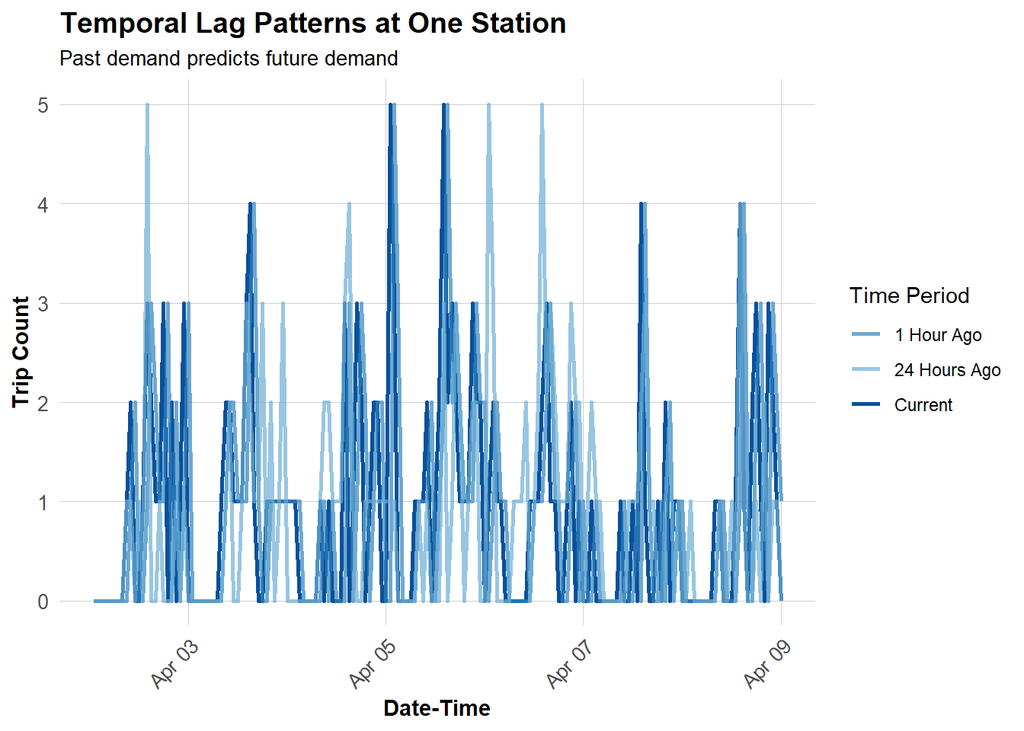

```r
# Sample one station to visualize
example_station <- study_panel_complete %>%
  filter(start_station == first(start_station)) %>%
  head(168)  # One week

# Plot actual vs lagged demand
ggplot(example_station, aes(x = interval60)) +
  geom_line(aes(y = Trip_Count, color = "Current"), linewidth = 1) +
  geom_line(aes(y = lag1Hour, color = "1 Hour Ago"), linewidth = 1, alpha = 0.7) +
  geom_line(aes(y = lag1day, color = "24 Hours Ago"), linewidth = 1, alpha = 0.7) +
  scale_color_manual(values = c(
    "Current" = "#08519c",
    "1 Hour Ago" = "#3182bd",
    "24 Hours Ago" = "#6baed6"
  )) +
  labs(
    title = "Temporal Lag Patterns at One Station",
    subtitle = "Past demand predicts future demand",
    x = "Date-Time",
    y = "Trip Count",
    color = "Time Period"
  ) +
  plotTheme
```

# TEMPORAL TRAIN/TEST SPLIT

**CRITICAL:** We must train on PAST data and test on FUTURE data!

## Why Temporal Validation Matters

In real operations, at 6:00 AM on March 15, we need to predict demand for March 15-31. We have data from Jan 1 - March 14, but NOT from March 15-31 (it hasn’t happened yet!).

**Wrong approach:** Train on weeks 10-13, test on weeks 1-9 (predicting past from future!)

```r
early_stations <- study_panel_complete %>%
  filter(date < as.Date("2025-06-01")) %>%
  filter(Trip_Count > 0) %>%
  distinct(start_station) %>%
  pull(start_station)

late_stations <- study_panel_complete %>%
  filter(date >= as.Date("2025-06-01")) %>%
  filter(Trip_Count > 0) %>%
  distinct(start_station) %>%
  pull(start_station)

common_stations <- intersect(early_stations, late_stations)

study_panel_complete <- study_panel_complete %>%
  filter(start_station %in% common_stations)

train <- study_panel_complete %>%
  filter(date < as.Date("2025-06-01"))

test <- study_panel_complete %>%
  filter(date >= as.Date("2025-06-01"))

cat("Training observations:", format(nrow(train), big.mark = ","), "\n")
```

```
Training observations: 356,817
```

```r
cat("Testing observations:", format(nrow(test), big.mark = ","), "\n")
```

```
Testing observations: 179,280
```

```r
cat("Training date range:", min(train$date), "to", max(train$date), "\n")
```

```
Training date range: 20180 to 20239
```

```r
cat("Testing date range:", min(test$date), "to", max(test$date), "\n")
```

```
Testing date range: 20240 to 20269
```

#BUILD PREDICTIVE MODELS

We’ll build 5 models with increasing complexity to see what improves predictions.

## Model 1: Baseline (Time + Weather)

```r
# Create day of week factor with treatment (dummy) coding
train <- train %>%
  mutate(dotw_simple = factor(dotw, levels = c("Mon", "Tue", "Wed", "Thu", "Fri", "Sat", "Sun")))

# Set contrasts to treatment coding (dummy variables)
contrasts(train$dotw_simple) <- contr.treatment(7)

# Now run the model
model1 <- lm(
  Trip_Count ~ as.factor(hour) + dotw_simple + Temperature + Precipitation,
  data = train
)

summary(model1)
```

```
Call:
lm(formula = Trip_Count ~ as.factor(hour) + dotw_simple + Temperature +
    Precipitation, data = train)

Residuals:
    Min      1Q  Median      3Q     Max
-1.6443 -0.6643 -0.2072  0.1885 25.5281

Coefficients:
                   Estimate Std. Error t value             Pr(>|t|)
(Intercept)       -0.562997   0.016443 -34.239 < 0.0000000000000002 ***
as.factor(hour)1  -0.045368   0.013166  -3.446             0.000569 ***
as.factor(hour)2  -0.061303   0.013171  -4.654   0.0000032500898230 ***
as.factor(hour)3  -0.100862   0.013181  -7.652   0.0000000000000198 ***
as.factor(hour)4  -0.079563   0.013202  -6.027   0.0000000016748796 ***
as.factor(hour)5   0.012345   0.013214   0.934             0.350181
as.factor(hour)6   0.230947   0.013172  17.534 < 0.0000000000000002 ***
as.factor(hour)7   0.488917   0.013183  37.088 < 0.0000000000000002 ***
as.factor(hour)8   0.843541   0.013192  63.941 < 0.0000000000000002 ***
as.factor(hour)9   0.632122   0.013219  47.820 < 0.0000000000000002 ***
as.factor(hour)10  0.512446   0.013189  38.853 < 0.0000000000000002 ***
as.factor(hour)11  0.550311   0.013158  41.823 < 0.0000000000000002 ***
as.factor(hour)12  0.586445   0.013129  44.667 < 0.0000000000000002 ***
as.factor(hour)13  0.612806   0.013113  46.734 < 0.0000000000000002 ***
as.factor(hour)14  0.636030   0.013105  48.533 < 0.0000000000000002 ***
as.factor(hour)15  0.723483   0.013111  55.180 < 0.0000000000000002 ***
as.factor(hour)16  0.882073   0.013121  67.225 < 0.0000000000000002 ***
as.factor(hour)17  1.182834   0.013137  90.040 < 0.0000000000000002 ***
as.factor(hour)18  0.943536   0.013153  71.734 < 0.0000000000000002 ***
as.factor(hour)19  0.659582   0.013155  50.140 < 0.0000000000000002 ***
as.factor(hour)20  0.409388   0.013153  31.124 < 0.0000000000000002 ***
as.factor(hour)21  0.264747   0.013146  20.138 < 0.0000000000000002 ***
as.factor(hour)22  0.181382   0.013126  13.819 < 0.0000000000000002 ***
as.factor(hour)23  0.082640   0.013111   6.303   0.0000000002923119 ***
dotw_simple2       0.030487   0.007324   4.163   0.0000314426261615 ***
dotw_simple3       0.002196   0.007099   0.309             0.757007
dotw_simple4       0.061751   0.007064   8.742 < 0.0000000000000002 ***
dotw_simple5      -0.016229   0.007080  -2.292             0.021898 *
dotw_simple6      -0.035651   0.007083  -5.033   0.0000004819561770 ***
dotw_simple7      -0.086228   0.007269 -11.863 < 0.0000000000000002 ***
Temperature        0.012186   0.000203  60.027 < 0.0000000000000002 ***
Precipitation     -0.810239   0.093233  -8.690 < 0.0000000000000002 ***
---
Signif. codes:  0 '***' 0.001 '**' 0.01 '*' 0.05 '.' 0.1 ' ' 1

Residual standard error: 1.123 on 356785 degrees of freedom
Multiple R-squared:  0.1115,    Adjusted R-squared:  0.1114
F-statistic:  1445 on 31 and 356785 DF,  p-value: < 0.00000000000000022
```

The model uses Monday as the baseline. Each coefficient represents the difference in expected trips per station-hour compared to Monday - dow_simple2 = Tuesday..

**Weekday Pattern (Tue-Fri):**

- Tuesday and Thursday have positive coefficients (**+0.031** and **+0.062**), while Wednesday is almost the same as Monday (**+0.002**)
- Friday is slightly below Monday (**-0.016**)
- This suggests weekday ridership is fairly stable, but Thursday appears strongest and Friday is slightly weaker

**Weekend Pattern (Sat-Sun):**

- Both weekend days have negative coefficients (**-0.036** for Saturday and **-0.087** for Sunday)
- This means FEWER trips per station-hour than Monday

**Hourly Interpretation**

## Model 2: Add Temporal Lags

```r
model2 <- lm(
  Trip_Count ~ as.factor(hour) + dotw_simple + Temperature + Precipitation +
    lag1Hour + lag3Hours + lag1day,
  data = train
)

summary(model2)
```

```
Call:
lm(formula = Trip_Count ~ as.factor(hour) + dotw_simple + Temperature +
    Precipitation + lag1Hour + lag3Hours + lag1day, data = train)

Residuals:
     Min       1Q   Median       3Q      Max
-10.6914  -0.4698  -0.1333   0.1079  20.6812

Coefficients:
                    Estimate Std. Error t value             Pr(>|t|)
(Intercept)       -0.2729705  0.0145909 -18.708 < 0.0000000000000002 ***
as.factor(hour)1   0.0017587  0.0116603   0.151              0.88011
as.factor(hour)2   0.0168768  0.0116676   1.446              0.14805
as.factor(hour)3   0.0037983  0.0116808   0.325              0.74505
as.factor(hour)4   0.0360673  0.0117016   3.082              0.00205 **
as.factor(hour)5   0.1060939  0.0117143   9.057 < 0.0000000000000002 ***
as.factor(hour)6   0.2502623  0.0116866  21.414 < 0.0000000000000002 ***
as.factor(hour)7   0.3865767  0.0117172  32.992 < 0.0000000000000002 ***
as.factor(hour)8   0.5796033  0.0117726  49.233 < 0.0000000000000002 ***
as.factor(hour)9   0.3027254  0.0117842  25.689 < 0.0000000000000002 ***
as.factor(hour)10  0.2453687  0.0117142  20.946 < 0.0000000000000002 ***
as.factor(hour)11  0.2663490  0.0116923  22.780 < 0.0000000000000002 ***
as.factor(hour)12  0.3142798  0.0116612  26.951 < 0.0000000000000002 ***
as.factor(hour)13  0.3398461  0.0116517  29.167 < 0.0000000000000002 ***
as.factor(hour)14  0.3434067  0.0116495  29.478 < 0.0000000000000002 ***
as.factor(hour)15  0.3998862  0.0116645  34.282 < 0.0000000000000002 ***
as.factor(hour)16  0.4905047  0.0116992  41.926 < 0.0000000000000002 ***
as.factor(hour)17  0.6700103  0.0117764  56.894 < 0.0000000000000002 ***
as.factor(hour)18  0.4023495  0.0117894  34.128 < 0.0000000000000002 ***
as.factor(hour)19  0.2247958  0.0117336  19.158 < 0.0000000000000002 ***
as.factor(hour)20  0.0716808  0.0117236   6.114       0.000000000971 ***
as.factor(hour)21  0.0490442  0.0116794   4.199       0.000026791574 ***
as.factor(hour)22  0.0511948  0.0116361   4.400       0.000010846334 ***
as.factor(hour)23  0.0233274  0.0116126   2.009              0.04456 *
dotw_simple2       0.0079043  0.0064859   1.219              0.22297
dotw_simple3      -0.0379021  0.0062905  -6.025       0.000000001690 ***
dotw_simple4       0.0286932  0.0062564   4.586       0.000004515009 ***
dotw_simple5      -0.0347392  0.0062722  -5.539       0.000000030511 ***
dotw_simple6      -0.0328722  0.0062733  -5.240       0.000000160628 ***
dotw_simple7      -0.0680869  0.0064390 -10.574 < 0.0000000000000002 ***
Temperature        0.0046518  0.0001815  25.624 < 0.0000000000000002 ***
Precipitation     -0.3817237  0.0825948  -4.622       0.000003808446 ***
lag1Hour           0.2547071  0.0016158 157.638 < 0.0000000000000002 ***
lag3Hours          0.1211534  0.0015806  76.649 < 0.0000000000000002 ***
lag1day            0.2508272  0.0015732 159.441 < 0.0000000000000002 ***
---
Signif. codes:  0 '***' 0.001 '**' 0.01 '*' 0.05 '.' 0.1 ' ' 1

Residual standard error: 0.9944 on 356782 degrees of freedom
Multiple R-squared:  0.3033,    Adjusted R-squared:  0.3032
F-statistic:  4567 on 34 and 356782 DF,  p-value: < 0.00000000000000022
```

**Question:** Did adding lags improve R²? Why or why not?

## Model 3: Add Demographics

```r
model3 <- lm(
  Trip_Count ~ as.factor(hour) + dotw_simple + Temperature + Precipitation +
    lag1Hour + lag3Hours + lag1day +
    Med_Inc + Percent_Taking_Transit + Percent_White,
  data = train
)

summary(model3)
```

```
Call:
lm(formula = Trip_Count ~ as.factor(hour) + dotw_simple + Temperature +
    Precipitation + lag1Hour + lag3Hours + lag1day + Med_Inc +
    Percent_Taking_Transit + Percent_White, data = train)

Residuals:
     Min       1Q   Median       3Q      Max
-10.0993  -0.4693  -0.1384   0.1724  20.9271

Coefficients:
                             Estimate     Std. Error t value
(Intercept)            -0.41029136246  0.01609813731 -25.487
as.factor(hour)1       -0.00098219448  0.01160779009  -0.085
as.factor(hour)2        0.01198816949  0.01161524097   1.032
as.factor(hour)3       -0.00299184552  0.01162866942  -0.257
as.factor(hour)4        0.02849595969  0.01164956617   2.446
as.factor(hour)5        0.09942380546  0.01166201918   8.525
as.factor(hour)6        0.24690715090  0.01163398349  21.223
as.factor(hour)7        0.38900818326  0.01166439652  33.350
as.factor(hour)8        0.59020902996  0.01172096454  50.355
as.factor(hour)9        0.31753572871  0.01173388845  27.061
as.factor(hour)10       0.25894874898  0.01166378029  22.201
as.factor(hour)11       0.28312386548  0.01164318776  24.317
as.factor(hour)12       0.32877090733  0.01161133482  28.315
as.factor(hour)13       0.35345528143  0.01160158738  30.466
as.factor(hour)14       0.35816297362  0.01159983675  30.877
as.factor(hour)15       0.41639567047  0.01161548427  35.848
as.factor(hour)16       0.51047565197  0.01165160969  43.812
as.factor(hour)17       0.69595377511  0.01173203226  59.321
as.factor(hour)18       0.42985565424  0.01174606242  36.596
as.factor(hour)19       0.24849488016  0.01168805337  21.261
as.factor(hour)20       0.09306660318  0.01167665905   7.970
as.factor(hour)21       0.06330319225  0.01162934260   5.443
as.factor(hour)22       0.05968851550  0.01158456045   5.152
as.factor(hour)23       0.02692480870  0.01156033507   2.329
dotw_simple2            0.00920772620  0.00645669601   1.426
dotw_simple3           -0.03582562982  0.00626219247  -5.721
dotw_simple4            0.03060654601  0.00622824649   4.914
dotw_simple5           -0.03385184932  0.00624389062  -5.422
dotw_simple6           -0.03318792292  0.00624494095  -5.314
```

[output cut: 39 more lines]

```
dotw_simple7           < 0.0000000000000002 ***
Temperature            < 0.0000000000000002 ***
Precipitation           0.00000061608359066 ***
lag1Hour               < 0.0000000000000002 ***
lag3Hours              < 0.0000000000000002 ***
lag1day                < 0.0000000000000002 ***
Med_Inc                < 0.0000000000000002 ***
Percent_Taking_Transit < 0.0000000000000002 ***
Percent_White          < 0.0000000000000002 ***
---
Signif. codes:  0 '***' 0.001 '**' 0.01 '*' 0.05 '.' 0.1 ' ' 1

Residual standard error: 0.9899 on 356779 degrees of freedom
Multiple R-squared:  0.3095,    Adjusted R-squared:  0.3095
F-statistic:  4323 on 37 and 356779 DF,  p-value: < 0.00000000000000022
```

## Model 4: Add Station Fixed Effects

```r
model4 <- lm(
  Trip_Count ~ as.factor(hour) + dotw_simple + Temperature + Precipitation +
    lag1Hour + lag3Hours + lag1day +
    Med_Inc + Percent_Taking_Transit + Percent_White +
    as.factor(start_station),
  data = train
)

# Summary too long with all station dummies, just show key metrics
cat("Model 4 R-squared:", summary(model4)$r.squared, "\n")
```

```
Model 4 R-squared: 0.335023
```

```r
cat("Model 4 Adj R-squared:", summary(model4)$adj.r.squared, "\n")
```

```
Model 4 Adj R-squared: 0.334497
```

**What do station fixed effects capture?**

Station fixed effects capture persistent baseline differences across stations. In other words, some stations are simply busier than others because of their location and surrounding context, such as land use, transit connections, and neighborhood activity.

## Model 5: Add Rush Hour Interaction

```r
model5 <- lm(
  Trip_Count ~ as.factor(hour) + dotw_simple + Temperature + Precipitation +
    lag1Hour + lag3Hours + lag1day + rush_hour +
    Med_Inc + Percent_Taking_Transit + Percent_White +
    as.factor(start_station) +
    rush_hour * weekend,  # Rush hour effects different on weekends
  data = train
)

cat("Model 5 R-squared:", summary(model5)$r.squared, "\n")
```

```
Model 5 R-squared: 0.3386208
```

```r
cat("Model 5 Adj R-squared:", summary(model5)$adj.r.squared, "\n")
```

```
Model 5 Adj R-squared: 0.3380958
```

# MODEL EVALUATION

## Calculate Predictions and MAE

```r
# Get predictions on test set

# Create day of week factor with treatment (dummy) coding
test <- test %>%
  mutate(dotw_simple = factor(dotw, levels = c("Mon", "Tue", "Wed", "Thu", "Fri", "Sat", "Sun")))

# Set contrasts to treatment coding (dummy variables)
contrasts(test$dotw_simple) <- contr.treatment(7)

test <- test %>%
  mutate(
    pred1 = predict(model1, newdata = test),
    pred2 = predict(model2, newdata = test),
    pred3 = predict(model3, newdata = test),
    pred4 = predict(model4, newdata = test),
    pred5 = predict(model5, newdata = test)
  )

# Calculate MAE for each model
mae_results <- data.frame(
  Model = c(
    "1. Time + Weather",
    "2. + Temporal Lags",
    "3. + Demographics",
    "4. + Station FE",
    "5. + Rush Hour Interaction"
  ),
  MAE = c(
    mean(abs(test$Trip_Count - test$pred1), na.rm = TRUE),
    mean(abs(test$Trip_Count - test$pred2), na.rm = TRUE),
    mean(abs(test$Trip_Count - test$pred3), na.rm = TRUE),
    mean(abs(test$Trip_Count - test$pred4), na.rm = TRUE),
    mean(abs(test$Trip_Count - test$pred5), na.rm = TRUE)
  )
)

kable(mae_results,
      digits = 2,
      caption = "Mean Absolute Error by Model (Test Set)",
      col.names = c("Model", "MAE (trips)")) %>%
  kable_styling(bootstrap_options = c("striped", "hover"))
```

Mean Absolute Error by Model (Test Set)

| Model | MAE (trips) |
| --- | --- |
| 1. Time + Weather | 0.83 |
| 2. + Temporal Lags | 0.69 |
| 3. + Demographics | 0.69 |
| 4. + Station FE | 0.69 |
| 5. + Rush Hour Interaction | 0.69 |

## Visualize Model Comparison

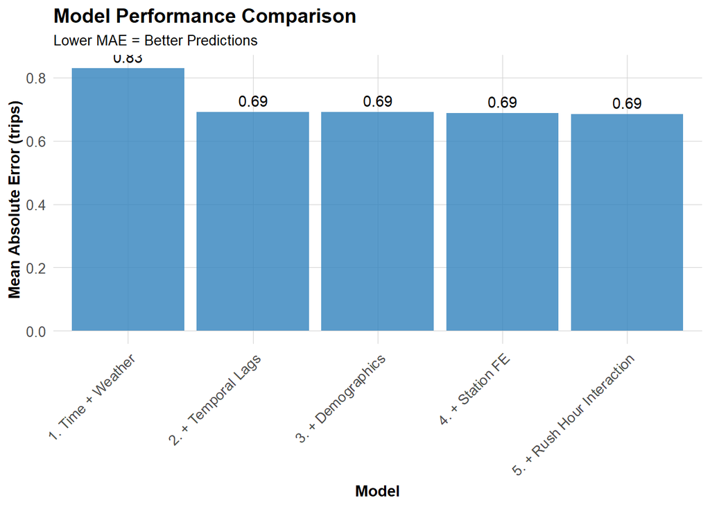

```r
ggplot(mae_results, aes(x = reorder(Model, -MAE), y = MAE)) +
  geom_col(fill = "#3182bd", alpha = 0.8) +
  geom_text(aes(label = round(MAE, 2)), vjust = -0.5) +
  labs(
    title = "Model Performance Comparison",
    subtitle = "Lower MAE = Better Predictions",
    x = "Model",
    y = "Mean Absolute Error (trips)"
  ) +
  plotTheme +
  theme(axis.text.x = element_text(angle = 45, hjust = 1))
```

**Question:** Which features gave us the biggest improvement?

# SPACE-TIME ERROR ANALYSIS

## Observed vs. Predicted

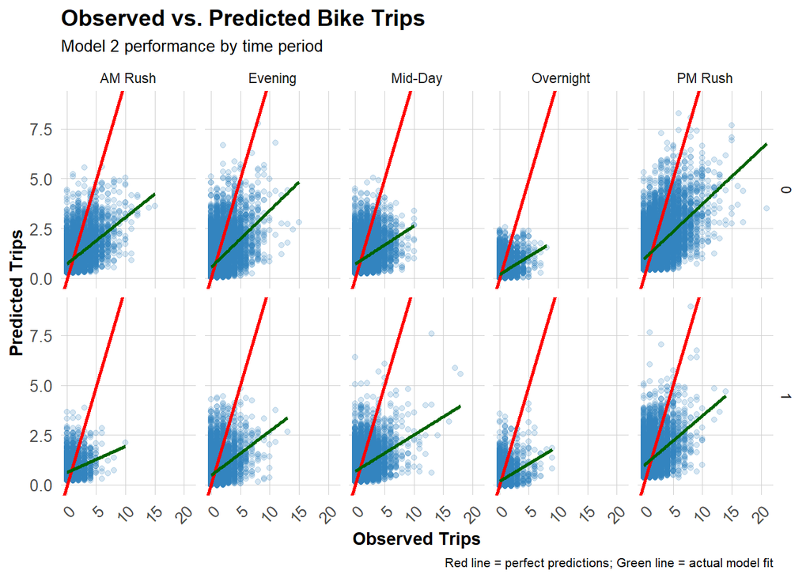

```r
test <- test %>%
  mutate(
    error = Trip_Count - pred2,
    abs_error = abs(error),
    time_of_day = case_when(
      hour < 7 ~ "Overnight",
      hour >= 7 & hour < 10 ~ "AM Rush",
      hour >= 10 & hour < 15 ~ "Mid-Day",
      hour >= 15 & hour <= 18 ~ "PM Rush",
      hour > 18 ~ "Evening"
    )
  )

# Scatter plot by time and day type
ggplot(test, aes(x = Trip_Count, y = pred2)) +
  geom_point(alpha = 0.2, color = "#3182bd") +
  geom_abline(slope = 1, intercept = 0, color = "red", linewidth = 1) +
  geom_smooth(method = "lm", se = FALSE, color = "darkgreen") +
  facet_grid(weekend ~ time_of_day) +
  labs(
    title = "Observed vs. Predicted Bike Trips",
    subtitle = "Model 2 performance by time period",
    x = "Observed Trips",
    y = "Predicted Trips",
    caption = "Red line = perfect predictions; Green line = actual model fit"
  ) +
  plotTheme
```

**Question:** Where is the model performing well? Where is it struggling?

## Spatial Error Patterns

Are prediction errors clustered in certain parts of Philadelphia?

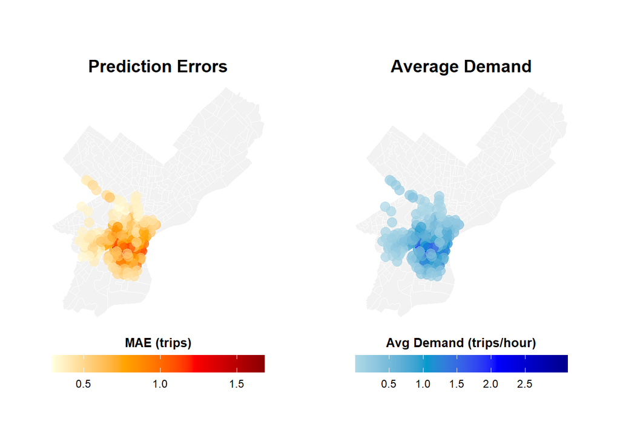

```r
# Calculate station errors
station_errors <- test %>%
  filter(!is.na(pred2)) %>%
  group_by(start_station, start_lat, start_lon) %>%
  summarize(
    MAE = mean(abs(Trip_Count - pred2), na.rm = TRUE),
    avg_demand = mean(Trip_Count, na.rm = TRUE),
    .groups = "drop"
  ) %>%
  filter(!is.na(start_lat), !is.na(start_lon))

# Map 1: Prediction Errors
p1 <- ggplot() +
  geom_sf(data = philly_census, fill = "grey95", color = "white", size = 0.1) +
  geom_point(
    data = station_errors,
    aes(x = start_lon, y = start_lat, color = MAE),
    size = 3.5,
    alpha = 0.7
  ) +
  scale_color_gradientn(
    colours = c("lightyellow", "orange", "red", "darkred"),
    name = "MAE (trips)",
    breaks = c(0.5, 1.0, 1.5),
    labels = c("0.5", "1.0", "1.5")
  ) +
  labs(title = "Prediction Errors") +
  mapTheme +
  theme(
    legend.position = "bottom",
    legend.title = element_text(size = 10, face = "bold"),
    legend.text = element_text(size = 9),
    plot.title = element_text(size = 14, face = "bold", hjust = 0.5)
  ) +
  guides(color = guide_colorbar(
    barwidth = 12,
    barheight = 1,
    title.position = "top",
    title.hjust = 0.5
  ))

# Map 2: Average Demand
p2 <- ggplot() +
  geom_sf(data = philly_census, fill = "grey95", color = "white", size = 0.1) +
  geom_point(
    data = station_errors,
    aes(x = start_lon, y = start_lat, color = avg_demand),
    size = 3.5,
    alpha = 0.7
  ) +
  scale_color_gradientn(
    colours = c("lightblue", "deepskyblue3", "blue", "darkblue"),
    name = "Avg Demand (trips/hour)",
    breaks = c(0.5, 1.0, 1.5, 2.0, 2.5),
    labels = c("0.5", "1.0", "1.5", "2.0", "2.5")
  ) +
  labs(title = "Average Demand") +
  mapTheme +
  theme(
    legend.position = "bottom",
    legend.title = element_text(size = 10, face = "bold"),
    legend.text = element_text(size = 9),
    plot.title = element_text(size = 14, face = "bold", hjust = 0.5)
  ) +
  guides(color = guide_colorbar(
    barwidth = 12,
    barheight = 1,
    title.position = "top",
    title.hjust = 0.5
  ))

# Combine
(p1 | p2)
```

**Question:** Do you see spatial clustering of errors? What neighborhoods have high errors?

Yes, the errors appear to be spatially clustered rather than randomly distributed. The highest prediction errors are concentrated in Center City and nearby parts of West Philadelphia. These same areas also show relatively high average demand, suggesting that the model has the most difficulty in the busiest parts of the network. Outer stations appear to have both lower demand and lower error.

## Temporal Error Patterns

When are we most wrong?

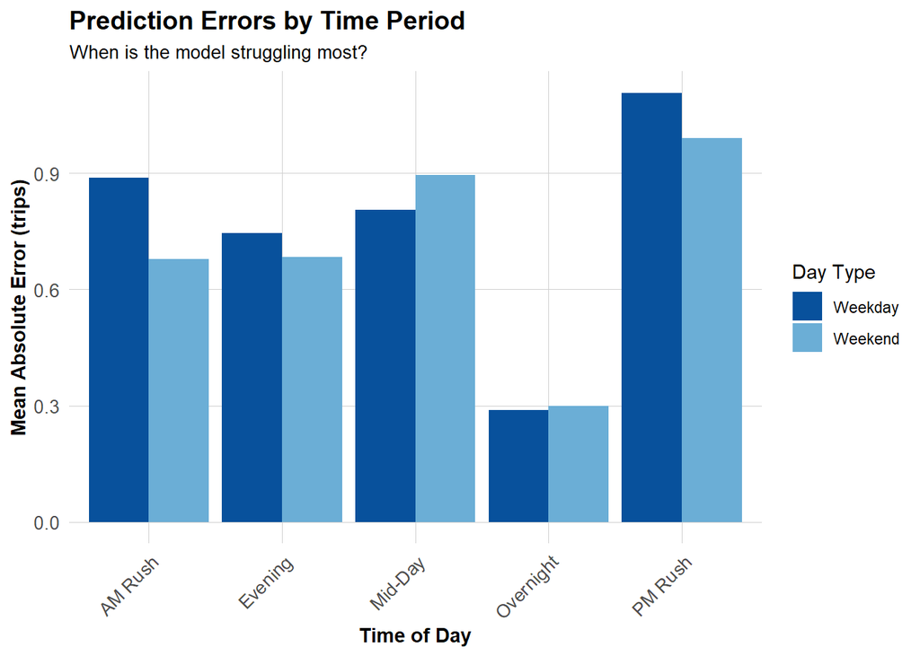

```r
# MAE by time of day and day type
temporal_errors <- test %>%
  group_by(time_of_day, weekend) %>%
  summarize(
    MAE = mean(abs_error, na.rm = TRUE),
    .groups = "drop"
  ) %>%
  mutate(day_type = ifelse(weekend == 1, "Weekend", "Weekday"))

ggplot(temporal_errors, aes(x = time_of_day, y = MAE, fill = day_type)) +
  geom_col(position = "dodge") +
  scale_fill_manual(values = c("Weekday" = "#08519c", "Weekend" = "#6baed6")) +
  labs(
    title = "Prediction Errors by Time Period",
    subtitle = "When is the model struggling most?",
    x = "Time of Day",
    y = "Mean Absolute Error (trips)",
    fill = "Day Type"
  ) +
  plotTheme +
  theme(axis.text.x = element_text(angle = 45, hjust = 1))
```

## Errors and Demographics

Are prediction errors related to neighborhood characteristics?

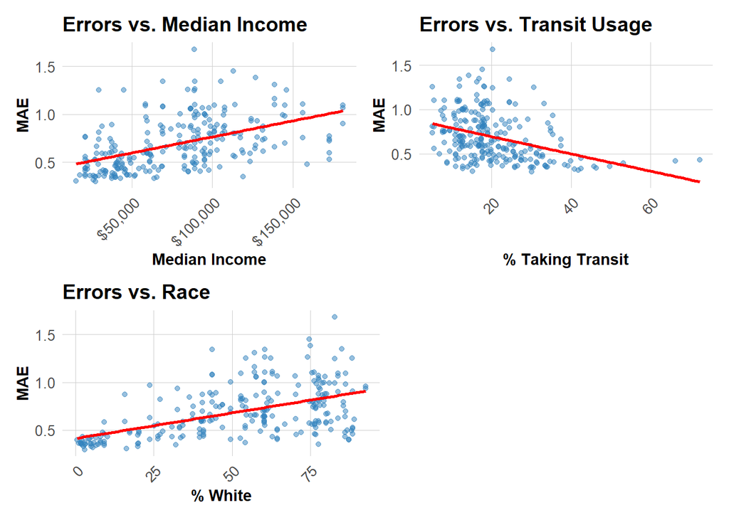

```r
# Join demographic data to station errors
station_errors_demo <- station_errors %>%
  left_join(
    station_attributes %>% select(start_station, Med_Inc, Percent_Taking_Transit, Percent_White),
    by = "start_station"
  ) %>%
  filter(!is.na(Med_Inc))

# Create plots
p1 <- ggplot(station_errors_demo, aes(x = Med_Inc, y = MAE)) +
  geom_point(alpha = 0.5, color = "#3182bd") +
  geom_smooth(method = "lm", se = FALSE, color = "red") +
  scale_x_continuous(labels = scales::dollar) +
  labs(title = "Errors vs. Median Income", x = "Median Income", y = "MAE") +
  plotTheme

p2 <- ggplot(station_errors_demo, aes(x = Percent_Taking_Transit, y = MAE)) +
  geom_point(alpha = 0.5, color = "#3182bd") +
  geom_smooth(method = "lm", se = FALSE, color = "red") +
  labs(title = "Errors vs. Transit Usage", x = "% Taking Transit", y = "MAE") +
  plotTheme

p3 <- ggplot(station_errors_demo, aes(x = Percent_White, y = MAE)) +
  geom_point(alpha = 0.5, color = "#3182bd") +
  geom_smooth(method = "lm", se = FALSE, color = "red") +
  labs(title = "Errors vs. Race", x = "% White", y = "MAE") +
  plotTheme

(p1 | p2) / (p3 | plot_spacer())
```

**Critical Question:** Are prediction errors systematically higher in certain demographic groups? What are the equity implications?

The scatterplots suggest that prediction errors may be systematically related to neighborhood characteristics. MAE appears to increase with median income and with the percentage of White residents, while it decreases as transit usage increases. This means the model may be less accurate in some demographic contexts than others, rather than making equally sized errors everywhere. From an equity perspective, this matters because uneven model performance could lead to better service planning in some neighborhoods and worse planning in others.

## **Compare results** to Q1 2025:

1. Compared with the original Q1 template, Q2 appears to have higher overall ridership, which is consistent with warmer spring and early summer conditions. The same broad commute structure remains visible, with strong morning and evening peaks, but Q2 demand also appears more elevated across midday and afternoon periods. These seasonal differences may affect both model fit and prediction error, since warmer-weather travel can be more frequent and potentially more variable than winter ridership.

## Part 3: Feature Engineering & model improvement

- Does this improve model fit?

```r
# 1. Add new features to the full panel
study_panel_fe <- study_panel_complete %>%
  arrange(start_station, interval60) %>%
  group_by(start_station) %>%
  mutate(
    # Nice biking weather indicator
    nice_weather = ifelse(Temperature >= 60 & Temperature <= 75 & Precipitation == 0, 1, 0),

    # Weekend + nice weather interaction
    weekend_nice_weather = ifelse(weekend == 1 & nice_weather == 1, 1, 0),

    # Same station, same approximate hour one week earlier
    lag1week = lag(Trip_Count, 168)
  ) %>%
  ungroup()

# 2. Re-create train/test split for Q2
train_fe <- study_panel_fe %>%
  filter(date < as.Date("2025-06-01"))

test_fe <- study_panel_fe %>%
  filter(date >= as.Date("2025-06-01"))

# 3. Re-create day-of-week factor
train_fe <- train_fe %>%
  mutate(dotw_simple = factor(dotw, levels = c("Mon", "Tue", "Wed", "Thu", "Fri", "Sat", "Sun")))

test_fe <- test_fe %>%
  mutate(dotw_simple = factor(dotw, levels = c("Mon", "Tue", "Wed", "Thu", "Fri", "Sat", "Sun")))

# 4. Keep only rows with complete lag information
train_fe <- train_fe %>%
  drop_na(lag1Hour, lag3Hours, lag1day, lag1week)

test_fe <- test_fe %>%
  drop_na(lag1Hour, lag3Hours, lag1day, lag1week)

# 5. Fit improved linear model
model_improved <- lm(
  Trip_Count ~ as.factor(hour) + dotw_simple + Temperature + Precipitation +
    lag1Hour + lag3Hours + lag1day + lag1week +
    nice_weather + weekend_nice_weather +
    as.factor(start_station),
  data = train_fe
)


# 6. Predict on test set
test_fe <- test_fe %>%
  mutate(
    pred_improved = predict(model_improved, newdata = test_fe)
  )

# 7. Calculate MAE for improved model
mae_improved <- mean(abs(test_fe$Trip_Count - test_fe$pred_improved), na.rm = TRUE)

cat("Improved Model MAE:", round(mae_improved, 4), "\n")
```

```
Improved Model MAE: 0.675
```

```r
# 8. Fit Poisson model for count data
poisson_model <- glm(
  Trip_Count ~ as.factor(hour) + dotw_simple + Temperature + Precipitation +
    lag1Hour + lag3Hours + lag1day + lag1week +
    nice_weather + weekend_nice_weather,
  family = poisson(link = "log"),
  data = train_fe
)


# 9. Predict from Poisson model
test_fe <- test_fe %>%
  mutate(
    pred_poisson = predict(poisson_model, newdata = test_fe, type = "response")
  )

# 10. Calculate MAE for Poisson model
mae_poisson <- mean(abs(test_fe$Trip_Count - test_fe$pred_poisson), na.rm = TRUE)

cat("Poisson Model MAE:", round(mae_poisson, 4), "\n")
```

```
Poisson Model MAE: 0.7229
```

```r
best_old_mae <- 0.83

comparison_table <- tibble(
  Model = c("Best Previous Model", "Improved Linear Model", "Poisson Model"),
  MAE = c(best_old_mae, mae_improved, mae_poisson)
)

print(comparison_table)
```

[output not shown]

```r
cat("\nRows in train_fe:", nrow(train_fe), "\n")
```

```
Rows in train_fe: 314985
```

```r
cat("Rows in test_fe:", nrow(test_fe), "\n")
```

```
Rows in test_fe: 179280
```

```r
cat("Train date range:", min(train_fe$date), "to", max(train_fe$date), "\n")
```

```
Train date range: 20187 to 20239
```

```r
cat("Test date range:", min(test_fe$date), "to", max(test_fe$date), "\n")
```

```
Test date range: 20240 to 20269
```

I added three new features based on the earlier error analysis:

**`nice_weather`** : an indicator for favorable biking weather, defined as temperatures between 60°F and 75°F with no precipitation

**`weekend_nice_weathe`**r: an interaction term to capture the idea that pleasant weather may increase leisure riding on weekends

**`lag1week`**: the trip count from the same station one week earlier, which helps capture repeated weekly demand patterns

These features were motivated by the patterns found in the earlier analysis. The temporal plots showed strong repeated demand cycles, which suggested that past demand from the same time last week could be useful. The Q2 context also made weather especially important, since spring and early summer biking is likely to be sensitive to pleasant conditions. In addition, weekend demand may be shaped by recreational travel, so a weekend-by-weather interaction was a reasonable extension.

## Critical Reflection

I also think there are real equity concerns. The errors are not random: they are clustered in some parts of the city and appear to vary with demographic characteristics. That means some neighborhoods may receive less accurate demand forecasts than others, which could translate into less reliable bike access. If that happens, the system could reinforce existing inequalities instead of improving service fairly across the city. To prevent this, Indego should evaluate model performance by neighborhood, not only citywide, and should set safeguards such as regular fairness audits and manual review for high-error areas. The model is also limited because it misses factors like holidays, school schedules, special events, and real-time disruptions. With more time and better data, I would add those features and also incorporate more detailed information about station capacity and rebalancing operations.